# Visualização de Dados

# Bibliotecas

```r
library(tidyverse)
```

# Introdução

Neste material, discutimos sobre a importância da visualização de dados, tanto para o processo de exploração dos dados, quanto para comunicação das descobertas, denominada aqui, etapa explanatória. No R nosso principal recurso para as visualizações é o pacote `ggplot2`, que implementa uma estrutura lógica denominada Gramática dos Gráficos.

# O que é Dataviz? É de comer?

Dataviz é a abreviação de *Data Vizualization*, ou, em português, **Visualização de dados**. Como o nome sugere, é uma forma de explorarmos os dados visualmente, por meio de gráficos!

> Você também pode encontrar o termo como datavis, com `s`, visto esta ser um sintaxe também aceita no R, devido ao inglês Britânico.

Esta etapa possui um papel crucial na análise de dados! Citando Ben Shneiderman, um importante nome da ciência da computação: “Visualização nos dá resposta para perguntas que nós não sabíamos que tínhamos”.

E no R, apesar de existirem muitos recursos padrão para a visualização de dados, como as funções: `plot()`, `hist()` e `boxplot()`.

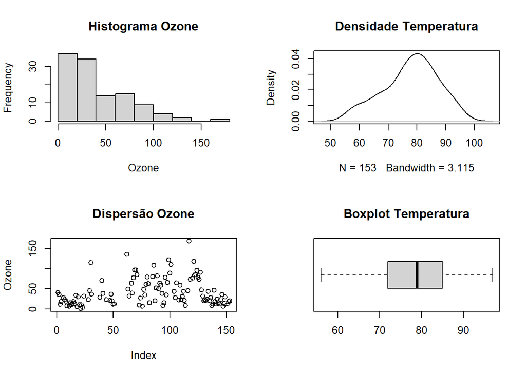

```r
Temperature <- airquality$Temp
Ozone <- airquality$Ozone

par(mfrow=c(2,2))
hist(Ozone, main = "Histograma Ozone")
plot((density(Temperature)), main = "Densidade Temperatura")
plot(Ozone, main = "Dispersão Ozone")
boxplot(Temperature, horizontal=TRUE, main = "Boxplot Temperatura")
```

É quando começamos a trabalhar com o `ggplot2` e suas bibliotecas tangentes que as possibilidades se potencializam.

# O pacote `ggplot2`

Dentre os muitos pacotes do R, o `ggplot2` é a maior referência em relação a visualização de dados. Isto porque nele é implementado o *Grammar of Graphics*, uma abstração segundo a qual cada elemento do gráfico é visto como um elemento sintático, de modo que passamos a ter um sistema de regras que permite uma estrutura única.

Sendo possível construir desde gráficos simples até visualizações complexas, isto por meio da mesma lógica utilizando a mesma lógica. Algumas das vantagens de usar o `ggplot2` são:

- Sintaxe única e estruturada
- Maior controle e versatilidade
- Portfólio amplo e em expansão
- Oferece recursos de design e “embelezamento” dos gráficos
- Fomenta a análise semântica dos dados
- Cada variável é representada de forma única
- Ter como base uma linguagem cientifica, que otimiza a reprodutibilidade
- Ao decodificar gráficos, tornamos a sua comunicação mais clara e intencional

Mas nem tudo são flores, o `ggplot2` tem um contra importante aqui que é a **curva de aprendizado**. Por ter uma gramática própria, leva um tempo para entendê-la e domina-la. Mas uma vez superada a barreira inicial, é difícil enxergar visualização de dados de outra maneira.

> eu nunca encontrei um ex-ggploter ;p

## As camadas do `ggplot2`

No `ggplot()` o gráfico é construído a partir de um mapeamento de elementos, feito por camadas. Sendo necessário para tal indicar quais elementos dos dados devem ser considerados. Para construir isso na prática, temos a estrutura de código abaixo:

```r
dados %>%
  ggplot(aesthetics()) +
    geometries(statistics()) +
    facets() +
    themes() +
    coord() +
    scales()
```

> Note que, depois de passar o conjunto de dados pelo pipe (`%>%`), a função `ggplot()` encadeia os elementos pelo operador `+`, e não mais pelo pipe – mas não se preocupe, se você confundir, o próprio R te dá um toque via mensagem ;)

Os principais elementos do `ggplot2` são:

- `{data}` – *Basics*: dados que serão utilizados no gráfico;
- `{aesthetic}` – *Aes*: mapeamento dos dados para os componentes visuais – usualmente denominados mapeamentos estéticos (especificação do eixo x, y, cores, formas, etc);
- `{geometries}` – *Geoms* : objetos geométricos que serão utilizados no gráfico (escolha dos gráficos!);
- `{facets}` – *Faceting* : apresenta as visualizações segundo subgrupos, ou seja, segmentações que você faz nos dados (como um gráfico para cada categoria, por exemplo);
- `{themes}` – *Themes* : redefine o layout visual do gráfico, sem mexer nos dados, mas em elementos de design (algo como a seção de “estilos de gráficos” do excel);
- `{coord}` – *Coordinate Systems* : organiza as coordenadas/eixos em que objetos geométricos irão aparecer – usualmente trabalhamos com [sistemas de coordenadas cartesiano](https://pt.wikipedia.org/wiki/Sistema_de_coordenadas_cartesiano) (aqui podemos manusear a apresentação dos eixos);
- `{statistics}` – *Stats* : transforma os dados considerando resumos estatísticos, como variância ou média. Normalmente aplicamos estas transformações antes da visualização, mas com o Stats, podemos contemplar esta etapa como uma camada do gráfico.

> existe também o `{scales}`, que apesar de não ser uma camada, mas sim uma `função wrapper` das `{aesthetics}`, possui um uso tão relevante dentro do contexto do ggplot, que vale ser citado aqui. Na prática o `{scales}` é como se fosse uma camada, responsável por adaptar os mapeamentos estéticos para outros contextos, como alteração de padrões de cores (permitindo utilizar uma paleta de cores acessível para daltônicos por exemplo), mudança na apresentação de um eixo (formatando a apresentação de uma variável segundo padrões de data), etc.

## cheat sheet

Aqui você terá uma referência poderosa, particularmente importante no início da sua jornada. Uma “folha de dicas” com imagens e exemplos que podem te auxiliar a decidir em questões como:

- quais geometrias você pode ou não aplicar, considerando o tipo e a quantidade das variáveis envolvidas?
- quais as estéticas obrigatórias para cada geom?
- qual a sintaxe que deve ser utilizada para cada camada?
- quais os principais `scales` que podemos utilizar?

[figure not shown]

CheatSheet ggplot2 (folha 01 e 02)

E apesar de todas essas possibilidades, você pode focar inicialmente em apenas três camadas, visto se tratarem de componentes obrigatórios para todo e qualquer gráfico: dados (`data`), mapeamentos estéticos (`aesthetic`), e objetos geométricos (`geometries`). No caso:

```r
  dados %>%
    ggplot(aesthetic) +
      geometries()
```

Vamos começar por elas!